# An Introduction to the ‘adjustedCurves’ Package

### Direct Standardization

Let’s again start with the *Direct Standardization* method. Instead of using a simple **coxph** method, we need to use a model for the time-to-event process which takes the multiple event-types into account. One such method is the *Cause-Specific Cox-Regression* model. A simple implementation of this model is contained in the **riskRegression** R-Package.

```r
# it is important to use X=TRUE in the coxph function call
outcome_model <- riskRegression::CSC(Hist(time, event) ~ x1 + x2 + x3 + x4 + x5 + x6 + group,
                                     data=data)
```

This model can then be used in a call to the **adjustedcif** function, as shown below:

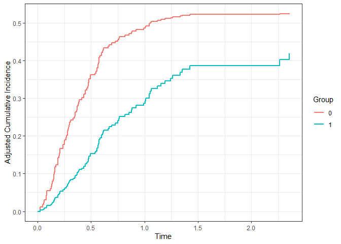

```r
adjcif <- adjustedcif(data=data,
                      variable="group",
                      ev_time="time",
                      event="event",
                      method="direct",
                      outcome_model=outcome_model,
                      cause=1,
                      conf_int=T)
plot(adjcif)
```

This shows the confounder-adjusted cumulative incidence functions for cause = 1. By setting cause to 2 we get the confounder-adjusted cumulative incidence functions for the other cause:

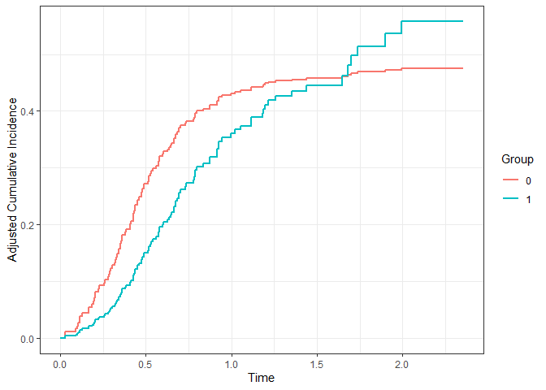

```r
adjcif <- adjustedcif(data=data,
                      variable="group",
                      ev_time="time",
                      event="event",
                      method="direct",
                      outcome_model=outcome_model,
                      cause=2,
                      conf_int=T)
plot(adjcif)
```

### Inverse Probability of Treatment Weighting

The IPTW estimator can be used exactly the same way as we did with the *adjustedsurv* function:

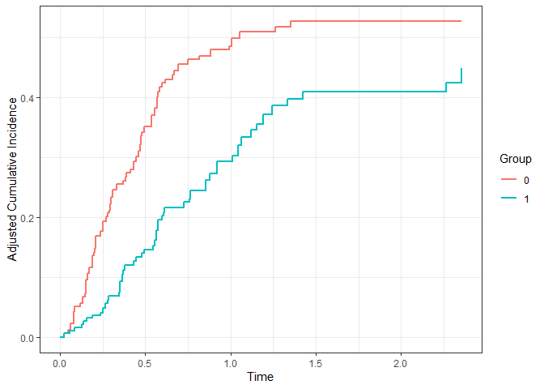

```r
treatment_model <- glm(group ~ x1 + x2 + x3 + x4 + x5 + x6,
                       data=data, family="binomial"(link="logit"))

adjcif <- adjustedcif(data=data,
                      variable="group",
                      ev_time="time",
                      event="event",
                      method="iptw",
                      treatment_model=treatment_model,
                      cause=1,
                      conf_int=T)
plot(adjcif)
```

The other estimators can be used using essentially the same syntax.

## Adjusted Curves with more than two treatments

First we again create a simulated data set (for single event survival data). The function is only able to create binary treatment variables, but we can simply resample all occurences of 1 into 1 and 2, creating 3 treatments, where 1 and 2 have an identical treatment effect and selection process:

```r
# set random number generator seed to make this reproducible
set.seed(41)

# simulate standard survival data with 300 rows
data <- sim_confounded_surv(n=300)

# add another group (NOTE: this is done only to showcase the method and does not
# reflect what should be done in real situations)
data$group[data$group==1] <- sample(c(1, 2), size=nrow(data[data$group==1,]),
                                          replace=T)

# code the grouping variable as a factor
data$group <- as.factor(data$group)
```

The Direct Adjusted survival curves can be calculated exactly as before:

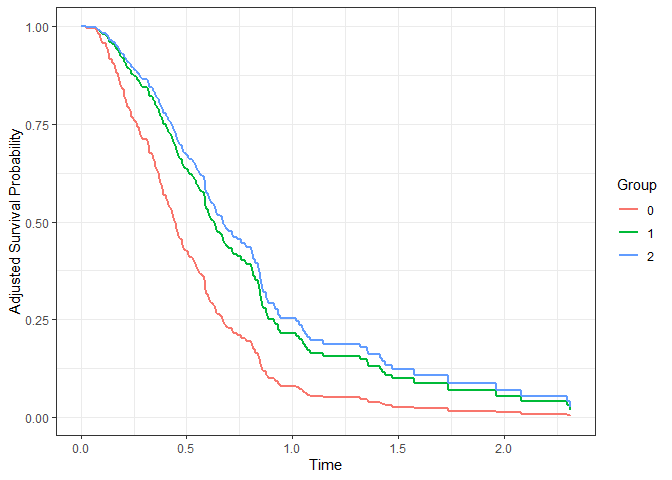

```r
outcome_model <- survival::coxph(Surv(time, event) ~ x1 + x2 + x3 + x4 + x5 + x6 + group,
                                 data=data, x=TRUE)

adjsurv <- adjustedsurv(data=data,
                        variable="group",
                        ev_time="time",
                        event="event",
                        method="direct",
                        outcome_model=outcome_model,
                        conf_int=T)
plot(adjsurv)
```

For the IPTW based estimates we first fit a multinomial logistic regression model using the *multinom* function from the *nnet* R-Package and use it with the same code as before:

```r
treatment_model <- nnet::multinom(group ~ x1 + x2 + x3 + x4 + x5 + x6, data=data)
```

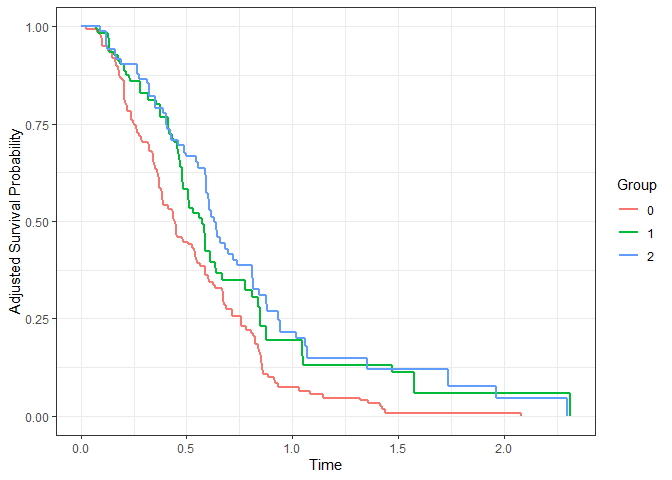

```r
adjsurv <- adjustedsurv(data=data,
                        variable="group",
                        ev_time="time",
                        event="event",
                        method="iptw_km",
                        treatment_model=treatment_model,
                        conf_int=T)
plot(adjsurv)
```

## Calculating the adjusted restricted mean survival time

An alternative measure to hazard-ratios is the restricted mean survival time, which denotes the integral of the survival curve from time 0 up to a specified point in time (see Royston et al. 2013). A confounder adjusted version of this statistic can be calculated by simply integrating the confounder adjusted survival curves instead of a normal Kaplan-Meier curve (Conner et al. 2019). The **adjustedCurves** package allows the user to do this by simply calling the *adjusted_rmst* function on a previously created *adjustedsurv* object:

```r
adjusted_rmst(adjsurv, to=1)
```

```
## ------------------------------------------------------------------
## Confounder-Adjusted Restricted Mean Survival Time
## ------------------------------------------------------------------
##
## Using the interval: 0 to 1
##
##            RMST
## Group=0 0.49882
## Group=1 0.59543
## Group=2 0.64151
## ------------------------------------------------------------------
```

The function returns adjusted RMST for every level of the “group” variable. When bootstrapping was performed when calling the *adjustedsurv* function, standard deviations and confidence intervals can be calculated using this function as well by setting the *use_boot* argument to TRUE.

## Literature

Donald B. Rubin. “Estimating Causal Effects of Treatments in Randomized and Nonrandomized Studies”. In: Journal of Educational Psychology 66.5 (1974), pp. 688–701.

Judea Pearl. Causality: Models, Reasoning and Inference. 2nd ed. Cambridge: Cambridge University Press, 2009.

Arthur Chatton, Florent Le Borgne, Clemence Leyrat, and Yohann Foucher. G-Computation and Inverse Probability Weighting for Time-To-Event Outcomes: A Comparative Study. arXiv:2006.16859v1. 2020.

Robert W. Makuch. “Adjusted Survival Curve Estimation Using Covariates”. In: Journal of Chronic Diseases 35.6 (1982), pp. 437–443.

I-Ming Chang, Rebecca Gelman, and Marcello Pagano. “Corrected Group Prognostic Curves and Summary Statistics”. In: Journal of Chronic Diseases 35 (1982), pp. 669–674.

Jun Xie and Chaofeng Liu. “Adjusted Kaplan-Meier Estimator and Log-Rank Test with Inverse Probability of Treatment Weighting for Survival Data”. In: Statistics in Medicine 24 (2005), pp. 3089–3110.

James M. Robins and Andrea Rotnitzky. “Recovery of Information and Adjustment for Dependent Censoring Using Surrogate Markers”. In: AIDS Epidemiology: Methodological Issues. Ed. by Nicholas P. Jewell, Klaus Dietz, and Vernon T. Farewell. New York: Springer Science + Business Media, 1992, pp. 297–331.

Brice Maxime Hugues Ozenne, Thomas Harder Scheike, and Laila Staerk. “On the Estimation of Average Treatment Effects with Right-Censored Time to Event Outcome and Competing Risks”. In: Biometrical Journal 62 (2020), pp. 751–763.

Weixin Cai and Mark J. van der Laan. “One-Step Targeted Maximum Likelihood Estimation for Time-To-Event Outcomes”. In: Biometrics 76 (2020), pp. 722–733.

Patrick Royston and Mahesh K. B. Parmar. “Restricted Mean Survival Time: An Alternative to the Hazard Ratio for the Design and Analysis of Randomized Trials with a Time-To-Event Outcome”. In: BMC Medical Research Methodology 13.152 (2013).

Sarah C. Conner, Lisa M. Sullivan, Emelia J. Benjamin, Michael P. LaValley, Sandro Galea, and Ludovic Trinquart. “Adjusted Restricted Mean Survival Times in Observational Studies”. In: Statistics in Medicine 38 (2019), pp. 3832-3860.